# OSHA fatality inspections analysis

# Setup

## Download the inspections data

```r
file_date <- str_remove_all(Sys.Date(), "-") # Set file date

data_path <- "data"
data_dir <- "osha_inspections"
data_url <- "https://enfxfr.dol.gov/data_catalog/OSHA"
data_file <- paste0("osha_inspection_", file_date, ".csv.zip")

if (!file.exists(file.path(data_path, data_dir))) {
  dir.create(data_path)
  download.file(paste(data_url, data_file, sep = "/"),
                file.path(data_path, data_file))
  unzip(file.path(data_path, data_file),
        exdir = file.path(data_path, data_dir))
}
```

## Import the inspections data

Read in the data, converting non-date columns to character type to minimize data type errors.

```r
inspections <-
  list.files(
    path = file.path(data_path, data_dir),
    pattern = "*.csv",
    full.names = TRUE
  ) %>%
  map_dfr(
    read_csv,
    col_types = cols(
      .default = "c",
      open_date = col_date(),
      case_mod_date = col_date(),
      close_conf_date = col_date(),
      close_case_date = col_date()
    )
  )

count(inspections)
```

| n |
| --- |
| 4776855 |

## Filter to just OSHA-inspected workplaces

A five as the third digit of the reporting ID indicates a state office inspected the worksite.

```r
state_office_indicator <- "5"

osha_inspections <- inspections %>%
  filter(str_sub(reporting_id, 3, 3) != state_office_indicator)

count(osha_inspections)
```

| n |
| --- |
| 2461528 |

# Analysis

## How many safety inspections did OSHA conduct during the first three years of Trump’s presidency?

```r
safety <- "S"
trump_begin_date <- "2017-01-20"
trump_end_date <- "2020-01-20"

trump_inspections <- osha_inspections %>%
  filter(safety_hlth == safety,
           open_date >= trump_begin_date,
         open_date < trump_end_date,
         insp_scope != "D") # no non-inspections

count(trump_inspections)
```

| n |
| --- |
| 81589 |

## How many safety inspections were conducted during the last three years of Obama’s presidency?

```r
obama_begin_date <- "2014-01-20"

obama_inspections <- osha_inspections %>%
  filter(safety_hlth == safety,
         open_date >= obama_begin_date,
         open_date < trump_begin_date,
         insp_scope != "D") # no non-inspections

count(obama_inspections)
```

| n |
| --- |
| 85594 |

## What’s the difference?

```r
(
  count(trump_inspections) - count(obama_inspections)
) / count(obama_inspections) * 100
```

| n |
| --- |
| -4.679066 |

## What does this look like over time?

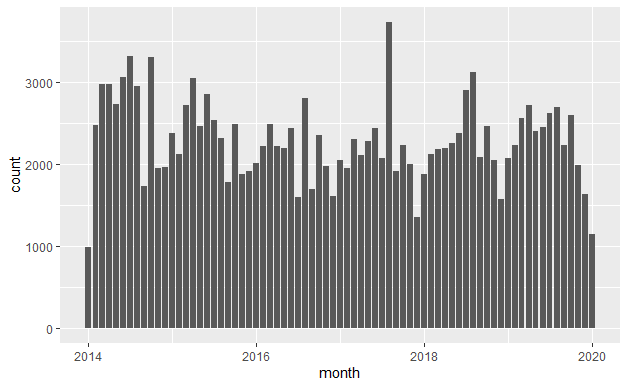

```r
inspections_by_month <- osha_inspections %>%
  filter(safety_hlth == safety &
           open_date >= obama_begin_date &
           open_date < trump_end_date &
           insp_scope != "D") %>%  # no non-inspections
  group_by(month = floor_date(open_date, unit = "month")) %>%
  summarize(count = n())
ggplot(inspections_by_month, aes(x = month, y = count)) +
  geom_col()

# Export this data
write_csv(inspections_by_month, "data/exported/inspections_by_month.csv")
ggsave("data/exported/inspections_by_month.png")
```

## Filter the OSHA inspections to only fatality/catastrophe safety inspections

| n |
| --- |
| 7741 |

## How many fat/cat safety inspections did OSHA conduct during the first 3.5 years of Trump’s presidency?

| n |
| --- |
| 3203 |

## Fat/cat inspections grouped by year

```r
fat_cat_inspections_by_year <- fat_cat_inspections %>%
  group_by(year = year(open_date)) %>%
  summarize(num_fatality_inspections = n()) %>%
  arrange(desc(year))
fat_cat_inspections_by_year
```

| year | num_fatality_inspections |
| --- | --- |
| 2020 | 537 |
| 2019 | 962 |
| 2018 | 922 |
| 2017 | 869 |
| 2016 | 924 |
| 2015 | 890 |
| 2014 | 924 |
| 2013 | 844 |
| 2012 | 733 |
| 2011 | 136 |

## When was the first fat/cat inspection reported?

```r
fat_cat_inspections %>% summarize(min(open_date))
```

| min(open_date) |
| --- |
| 2011-04-20 |

## Fat/cat inspections charted by year

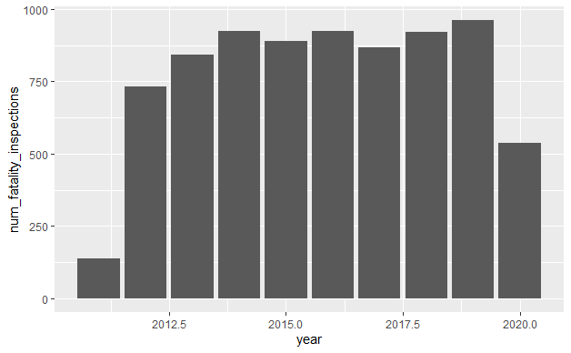

```r
ggplot(fat_cat_inspections_by_year,
       aes(x = year, y = num_fatality_inspections)) +
  geom_col()
```

## How many workplaces received any sort of OSHA safety inspection (including fat/cat inspections) when grouped by address and inspection date?

```r
osha_inspections_w_workplace <- osha_inspections %>%
  filter(safety_hlth == safety) %>%
  mutate(estab_address = toupper(str_replace_all(paste0(
    site_address, site_zip
  ), " ", "")))

n_distinct(osha_inspections_w_workplace %>%
  select(estab_address, open_date))
```

```
[1] 1625582
```

## How many workplaces received an OSHA safety fat/cat inspection when grouped by address and inspection date?

```r
accident_begin_date <- "2013-01-01"

osha_fatality_inspections_w_workplace <- osha_inspections_w_workplace %>%
  filter(insp_type == fat_cat, open_date >= accident_begin_date)

n_distinct(osha_fatality_inspections_w_workplace %>%
  select(estab_address, open_date))
```

[output not shown]

## Join the data frames to see every safety inspection (including fat/cat inspections) OSHA conducted prior to each workplace’s catastrophic/fatal accidents.

```r
osha_inspected_prior <-
  inner_join(osha_fatality_inspections_w_workplace,
             osha_inspections_w_workplace,
             by = "estab_address",
             suffix = c("_fatality", "_all")) %>%
  mutate(
    years_between = time_length(open_date_fatality - open_date_all, "year"),
    prior_inspection = years_between < 10
  ) %>%
  filter(open_date_fatality > open_date_all)
```

## And how many of these catastrophic/fatal accidents were there?

```r
n_distinct(osha_inspected_prior %>%
  select(estab_address, open_date_fatality))
```

```
[1] 859
```

## What does this look like for one address?

```r
osha_inspected_prior %>%
  filter(estab_address == "102-0166THROADFORESTHILLSNY11375") %>%
  select(estab_address, safety_hlth_fatality, safety_hlth_all, insp_type_fatality, insp_type_all, open_date_fatality, open_date_all, years_between, prior_inspection) %>%
  arrange(desc(open_date_fatality), desc(open_date_all))
```

| estab_address | safety_hlth_fatality | safety_hlth_all | insp_type_fatality | insp_type_all | open_date_fatality | open_date_all | years_between | prior_inspection |
| --- | --- | --- | --- | --- | --- | --- | --- | --- |

```r
osha_inspections %>%
  filter(site_address == "102-01 66TH ROAD" & site_city == "FOREST HILLS" & site_state == "NY" & site_zip == "11375" & safety_hlth == "S" & insp_type == "M" & open_date >= "2013-01-01") %>%
  arrange(desc(open_date))
```

| activity_nr | reporting_id | state_flag | estab_name | site_address | site_city | site_state | site_zip | owner_type | owner_code | adv_notice | safety_hlth | sic_code | naics_code | insp_type | insp_scope | why_no_insp | union_status | safety_manuf | safety_const | safety_marit | health_manuf | health_const | health_marit | migrant | mail_street | mail_city | mail_state | mail_zip | host_est_key | … |
| --- | --- | --- | --- | --- | --- | --- | --- | --- | --- | --- | --- | --- | --- | --- | --- | --- | --- | --- | --- | --- | --- | --- | --- | --- | --- | --- | --- | --- | --- | --- |
| 344783170 | 0215600 | NA | LONG ISLAND JEWISH-FOREST HILLS HOSPITAL | 102-01 66TH ROAD | FOREST HILLS | NY | 11375 | A | NA | N | S | NA | 622110 | M | B | I | A | NA | NA | NA | NA | NA | NA | NA | 102-01 66TH ROAD | FOREST HILLS | NY | 11375 | HOST_EST_KEY_VALUE | … |
| 344746623 | 0215600 | NA | LONG ISLAND JEWISH-FOREST HILLS HOSPITAL | 102-01 66TH ROAD | FOREST HILLS | NY | 11375 | A | NA | N | S | NA | 622110 | M | B | I | A | NA | NA | NA | NA | NA | NA | NA | 102-01 66TH ROAD | FOREST HILLS | NY | 11375 | HOST_EST_KEY_VALUE | … |
| 344747597 | 0215600 | NA | LONG ISLAND JEWISH-FOREST HILLS HOSPITAL | 102-01 66TH ROAD | FOREST HILLS | NY | 11375 | A | NA | N | S | NA | 622110 | M | B | I | A | NA | NA | NA | NA | NA | NA | NA | 102-01 66TH ROAD | FOREST HILLS | NY | 11375 | HOST_EST_KEY_VALUE | … |
| 344721857 | 0215600 | NA | LONG ISLAND JEWISH-FOREST HILLS HOSPITAL | 102-01 66TH ROAD | FOREST HILLS | NY | 11375 | A | NA | N | S | NA | 622110 | M | B | I | B | NA | NA | NA | NA | NA | NA | NA | 102-01 66TH ROAD | FOREST HILLS | NY | 11375 | HOST_EST_KEY_VALUE | … |

```r
osha_inspections %>%
  filter(site_address == "102-01 66TH ROAD" & site_city == "FOREST HILLS" & site_state == "NY" & site_zip == "11375" & safety_hlth == "S") %>%
  arrange(desc(open_date))
```

| activity_nr | reporting_id | state_flag | estab_name | site_address | site_city | site_state | site_zip | owner_type | owner_code | adv_notice | safety_hlth | sic_code | naics_code | insp_type | insp_scope | why_no_insp | union_status | safety_manuf | safety_const | safety_marit | health_manuf | health_const | health_marit | migrant | mail_street | mail_city | mail_state | mail_zip | host_est_key | … |
| --- | --- | --- | --- | --- | --- | --- | --- | --- | --- | --- | --- | --- | --- | --- | --- | --- | --- | --- | --- | --- | --- | --- | --- | --- | --- | --- | --- | --- | --- | --- |
| 344783170 | 0215600 | NA | LONG ISLAND JEWISH-FOREST HILLS HOSPITAL | 102-01 66TH ROAD | FOREST HILLS | NY | 11375 | A | NA | N | S | NA | 622110 | M | B | I | A | NA | NA | NA | NA | NA | NA | NA | 102-01 66TH ROAD | FOREST HILLS | NY | 11375 | HOST_EST_KEY_VALUE | … |
| 344746623 | 0215600 | NA | LONG ISLAND JEWISH-FOREST HILLS HOSPITAL | 102-01 66TH ROAD | FOREST HILLS | NY | 11375 | A | NA | N | S | NA | 622110 | M | B | I | A | NA | NA | NA | NA | NA | NA | NA | 102-01 66TH ROAD | FOREST HILLS | NY | 11375 | HOST_EST_KEY_VALUE | … |
| 344747597 | 0215600 | NA | LONG ISLAND JEWISH-FOREST HILLS HOSPITAL | 102-01 66TH ROAD | FOREST HILLS | NY | 11375 | A | NA | N | S | NA | 622110 | M | B | I | A | NA | NA | NA | NA | NA | NA | NA | 102-01 66TH ROAD | FOREST HILLS | NY | 11375 | HOST_EST_KEY_VALUE | … |
| 344721857 | 0215600 | NA | LONG ISLAND JEWISH-FOREST HILLS HOSPITAL | 102-01 66TH ROAD | FOREST HILLS | NY | 11375 | A | NA | N | S | NA | 622110 | M | B | I | B | NA | NA | NA | NA | NA | NA | NA | 102-01 66TH ROAD | FOREST HILLS | NY | 11375 | HOST_EST_KEY_VALUE | … |
| 303528186 | 0215600 | NA | NORTH SHORE UNIVERSITY HOSPITAL | 102-01 66TH ROAD | FOREST HILLS | NY | 11375 | A | 0000 | N | S | 8062 | 000000 | L | C | NA | N | NA | NA | NA | NA | NA | NA | NA | NA | NA | NA | 00000 | N158 000006670 | … |

## And how many of these catastrophic/fatal accidents were preceded by an inspection in the prior 10 years?

```r
n_distinct(osha_inspected_prior %>%
  filter(prior_inspection == TRUE,
         insp_scope_all != "D") %>%
    select(estab_address, open_date_fatality))
```

```
[1] 584
```

## How many inspections has OSHA conducted since COVID began?

That is, since the White House declared a national emergency on 3/13.

```r
covid_emergency_declared_date <- "2020-03-13"

covid_inspections <- osha_inspections %>%
  filter(open_date >= covid_emergency_declared_date,
         insp_scope != "D")

count(covid_inspections)
```

| n |
| --- |
| 5127 |

## How many inspections did OSHA conduct in the same period a year earlier?

| n |
| --- |
| 14549 |

## And what’s been the change?

| n |
| --- |
| -64.76046 |

## How many health inspections has OSHA conducted since COVID began?

That is, since the White House declared a national emergency on 3/13.

| n |
| --- |
| 1133 |

## How many health inspections did OSHA conduct in the same period a year earlier?

| n |
| --- |
| 2320 |

## And what’s been the change?

| n |
| --- |
| -51.16379 |